# Laboratório 1

Suzana de Lima

Março, 2021

# Questão 1

## Base de dados

Base de dados extraída do estudo Current Population Survey (CPS) de 1985, com 534 observações para explorar, entre outras coisas, se o valor do salário (valor por hora) difere entre homens e mulheres com características observadas similares.

```r
require(haven)
df <- read_dta("wages.dta")
```

As variáveis da base de dados:

- *education* - Anos de estudo;
- *south* - Indicador para estados do sudoeste americano;
- *female* - Indicador para mulheres;
- *workexp* - Anos de experiência no trabalho;
- *unionmember* - Indicador para pertencimento a sindicato;
- *wages* - Valor do salário por hora;
- *age* - Idade;
- *ethnicity* - Etnia (1:outros, 2:hispânico, 3:branco);
- *occupaton* - Ocupação (1:administrativo, 2:vendas, 3:sacerdotal, 4:serviço, 5:profissional liberal, 6:outros);
- *sector* - Setor (0:outro, 1:manufatura, 2:construção);
- *married* - Indicadora para estado civil casado.

## Análise Descritiva

### Tabela resumo

```r
require(kableExtra)
require(psych)
require(dplyr)
df %>%
  select(Estudo = education,"Experiência"=workexp,"Salário" = wages,Idade=age) %>%
  describe() %>%
  round(2) %>%
  select("Média"=mean,Desvio =sd,"Mínimo"=min, "Máximo"=max) %>%
  kable() %>%
  kable_paper("hover", full_width = F)
```

|  | Média | Desvio | Mínimo | Máximo |
| --- | --- | --- | --- | --- |
| Estudo | 13.02 | 2.62 | 2 | 18.0 |
| Experiência | 17.82 | 12.38 | 0 | 55.0 |
| Salário | 9.02 | 5.14 | 1 | 44.5 |
| Idade | 36.83 | 11.73 | 18 | 64.0 |

A média de idade entre os trabalhadores é de 37 anos, com média de 13 anos de estudos o salário médio por hora é de 9 (unidade de valor) com a experiência em média de 18 anos.

### Salário vs Gênero

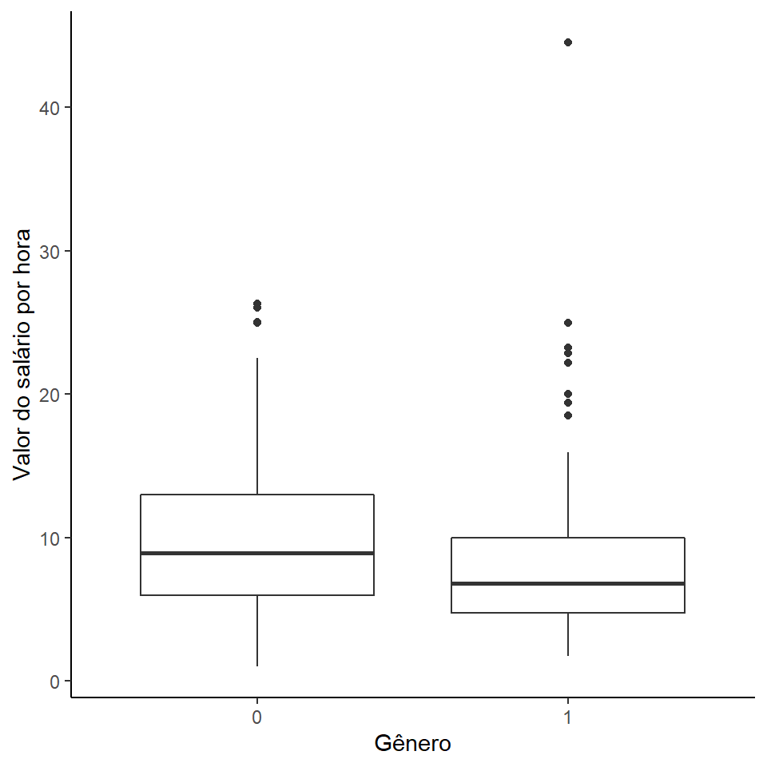

```r
require(ggplot2)
ggplot(df, aes(x=factor(female), y=wages)) +
  geom_boxplot() +
  scale_fill_brewer(palette="Set1")+
  labs(x= "Gênero", y="Valor do salário por hora")+
  theme_classic()
```

### Salário vs Anos de educação

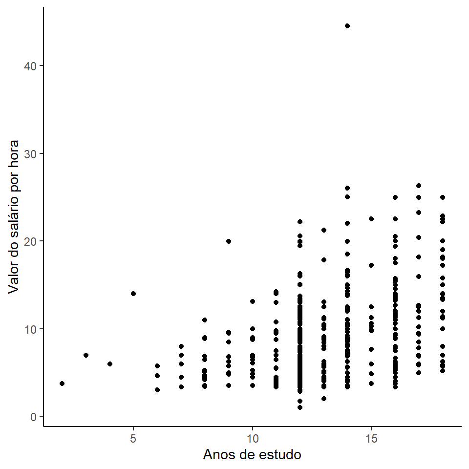

```r
ggplot(df, aes(x=education, y=wages)) +
  geom_point() +
  scale_fill_brewer(palette="Set1")+
  labs(x= "Anos de estudo", y="Valor do salário por hora")+
  theme_classic()
```

Aparentemente tem um tendência linear positiva bem fraca.

### Salário vs Experiência

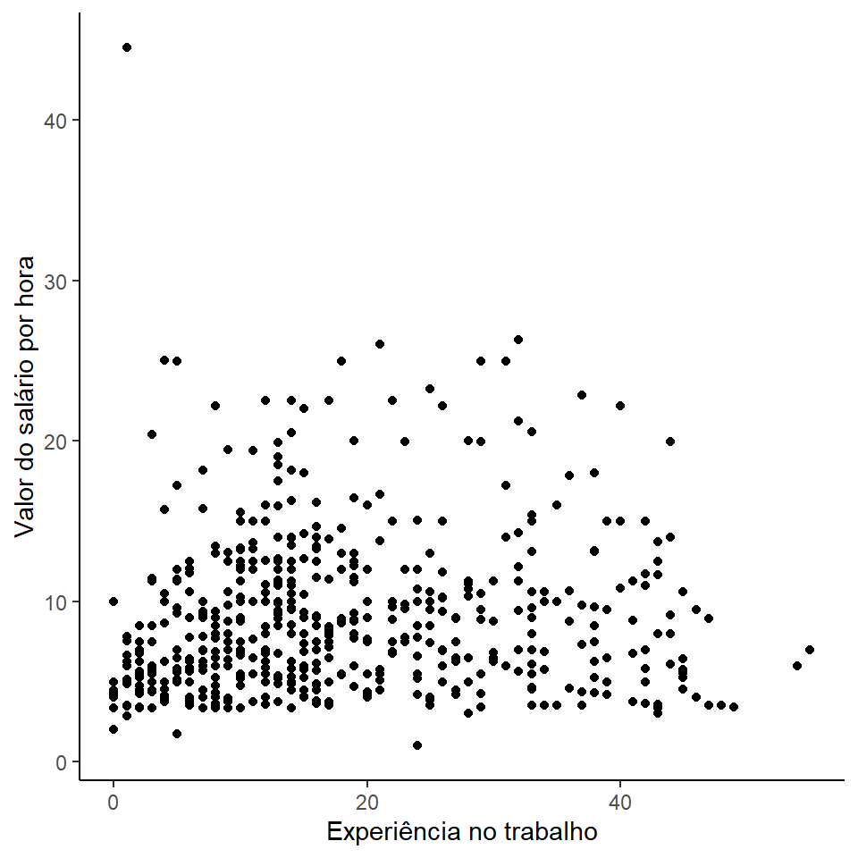

```r
ggplot(df, aes(x=workexp, y=wages)) +
  geom_point() +
  scale_fill_brewer(palette="Set1")+
  labs(x= "Experiência no trabalho", y="Valor do salário por hora")+
  theme_classic()
```

Nuvem de dados aleatória.

### Salário vs Sindicato

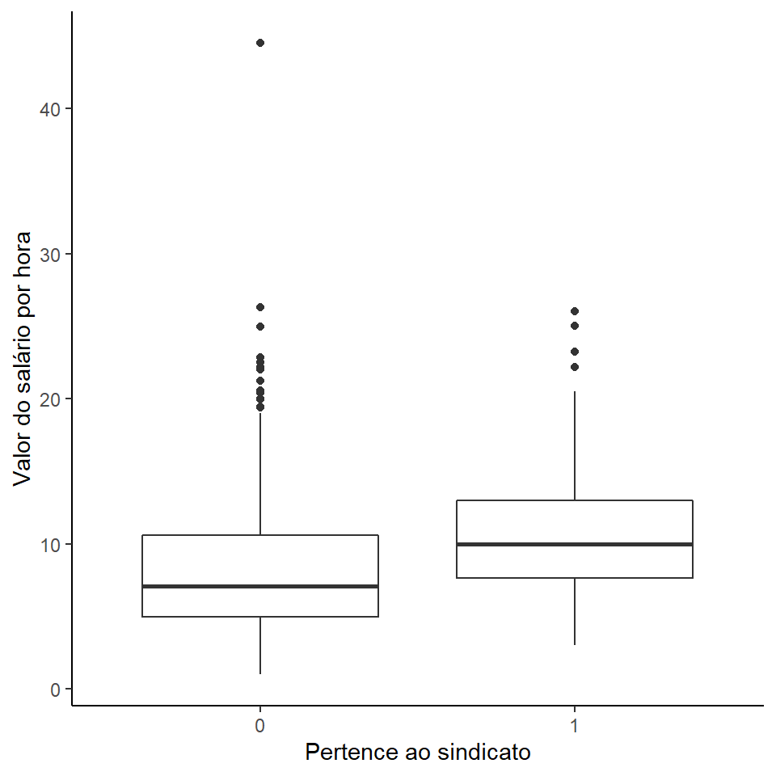

```r
ggplot(df, aes(x=factor(unionmember), y=wages)) +
  geom_boxplot() +
  scale_fill_brewer(palette="Set1")+
  labs(x= "Pertence ao sindicato", y="Valor do salário por hora")+
  theme_classic()
```

O salário por hora dos trabalhadores filiados ao sindicado tem maior mediana.

### Salário vs Região

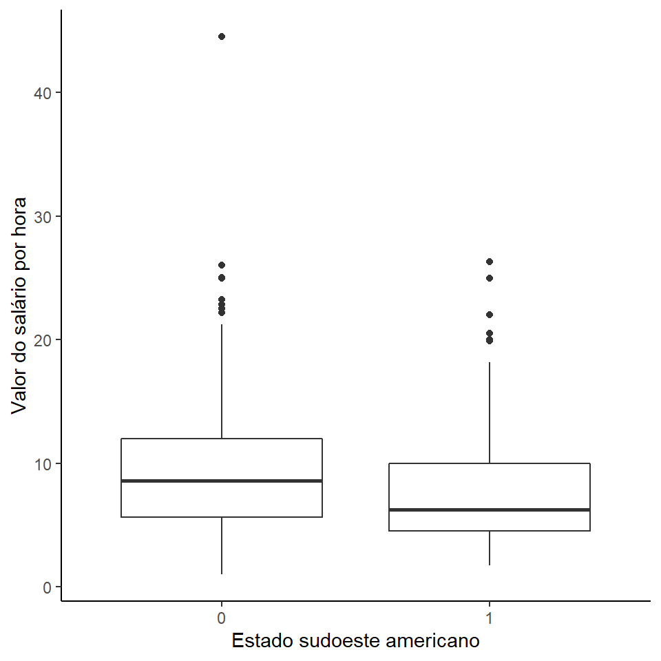

```r
ggplot(df, aes(x=factor(south), y=wages)) +
  geom_boxplot() +
  scale_fill_brewer(palette="Set1")+
  labs(x= "Estado sudoeste americano", y="Valor do salário por hora")+
  theme_classic()
```

### Salário vs Etnia

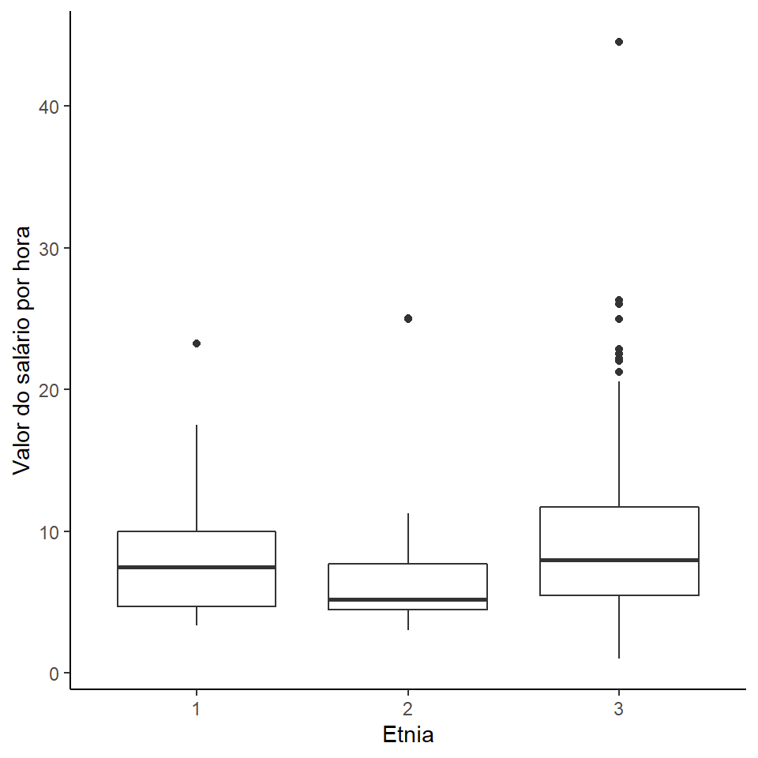

```r
ggplot(df, aes(x=factor(ethnicity), y=wages)) +
  geom_boxplot() +
  scale_fill_brewer(palette="Set1")+
  labs(x= "Etnia", y="Valor do salário por hora")+
  theme_classic()
```

Os trabalhadores branco tem maior variabilidade e maior mediana em relação ao salário por hora.

### Correlação

```r
cbind("Variáveis" = c("Educação","Experiência"),
      "Correlação"=round(c(cor(df$education,df$wages),cor(df$workexp,df$wages)),2)) %>%
  kable() %>%
  kable_paper("hover", full_width = F)
```

| Variáveis | Correlação |
| --- | --- |
| Educação | 0.38 |
| Experiência | 0.09 |

## Parte 1

### Modelo

```r
mod <- lm(wages~education+factor(south)+factor(female)+workexp+factor(ethnicity)+factor(unionmember), data = df)
require(broom)
tidy(mod) %>%
  kable() %>%
  kable_paper("hover", full_width = F)
```

| term | estimate | std.error | statistic | p.value |
| --- | --- | --- | --- | --- |
| (Intercept) | -4.5586403 | 1.3200278 | -3.4534427 | 0.0005981 |
| education | 0.9047976 | 0.0798530 | 11.3307962 | 0.0000000 |
| factor(south)1 | -0.7074520 | 0.4291303 | -1.6485717 | 0.0998325 |
| factor(female)1 | -2.1775755 | 0.3900228 | -5.5832002 | 0.0000000 |
| workexp | 0.1053003 | 0.0167423 | 6.2894839 | 0.0000000 |
| factor(ethnicity)2 | 0.7204435 | 1.0112740 | 0.7124118 | 0.4765257 |
| factor(ethnicity)3 | 1.0092761 | 0.5847414 | 1.7260211 | 0.0849308 |
| factor(unionmember)1 | 1.4708646 | 0.5119098 | 2.8732885 | 0.0042264 |

- O intercepto nesse caso não é interpretável;
- $\hat{education}$ controlando todas as outras variáveis, quando aumentar 1 ano aumenta em 0,90 o salário por hora;
- $\hat{south}$ ser de um estado do sudoeste americano, reduz na média em -0,71 em relação ao grupo 0, controlando as outras variáveis;
- $\hat{female}$ ser mulher reduz em média -2,18 o salário por hora em relação a ser homem, controlando as outras variáveis;
- $\hat{workexp}$ aumentando em um ano a experiência aumenta em média 0,10 o salário por hora, controlando as outras variáveis;
- $\hat{ethnicity2}$ ser hispânico aumenta em média o salário por hora em 0,72 em relação a outros, controlando as outras variáveis;
- $\hat{ethnicity3}$ ser branco aumenta em média o salário por hora em 1,01 em relação a outros, controlando as outras variáveis;
- $\hat{unionmember}$ ser membro de um sindicato aumenta 1,47 em média o salário por hora em relação a não pertencer, controlando as outras variáveis.

Tomando $\alpha = 0,05$ percebe-se que as variáveis *education*, *female*, *workexp* e *unionmember* foram significativos para o modelo.

### Análise de resíduos

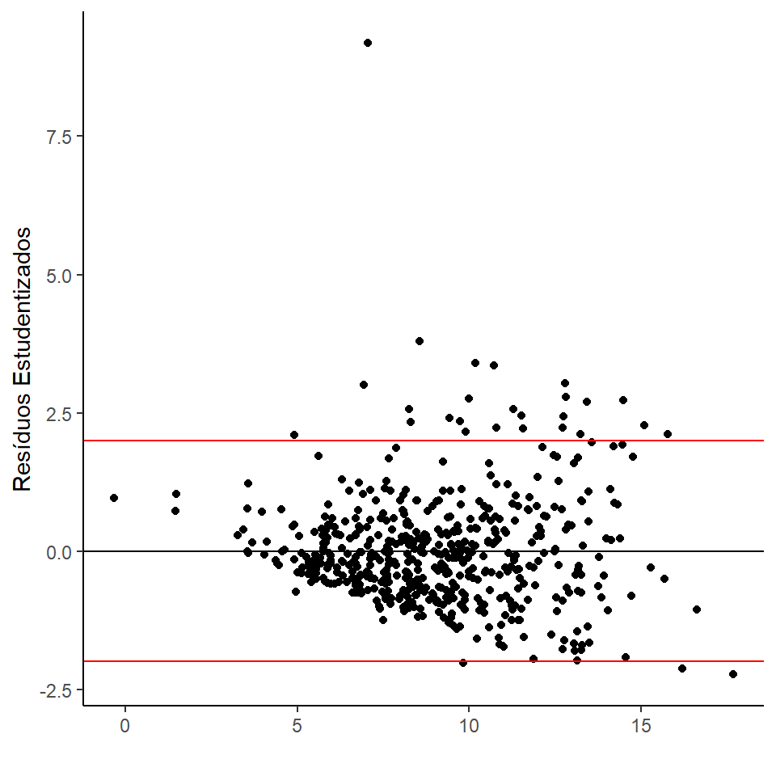

```r
ggplot(mod, aes(mod$fitted.values,rstudent(mod)))+
  geom_point()+
  xlab("")+
  ylab("Resíduos Estudentizados")+
  geom_hline(yintercept=0)+
  geom_hline(yintercept=2, color="red")+
  geom_hline(yintercept=-2, color="red")+
  theme_classic()
```

Aparentemente viola o presuposto de homocedasticidade e normalidade.

## Parte 2

### Modelo *log(wages)*

```r
mod_log <- lm(log(wages)~education+factor(south)+factor(female)+workexp+factor(ethnicity)+factor(unionmember), data = df)

tidy(mod_log) %>%
  kable() %>%
  kable_paper("hover", full_width = F)
```

| term | estimate | std.error | statistic | p.value |
| --- | --- | --- | --- | --- |
| (Intercept) | 0.6642802 | 0.1324900 | 5.0138135 | 0.0000007 |
| education | 0.0924922 | 0.0080148 | 11.5402131 | 0.0000000 |
| factor(south)1 | -0.1021168 | 0.0430714 | -2.3708710 | 0.0181056 |
| factor(female)1 | -0.2322306 | 0.0391462 | -5.9323853 | 0.0000000 |
| workexp | 0.0114562 | 0.0016804 | 6.8174835 | 0.0000000 |
| factor(ethnicity)2 | 0.0129352 | 0.1015007 | 0.1274394 | 0.8986414 |
| factor(ethnicity)3 | 0.1032245 | 0.0586900 | 1.7588097 | 0.0791913 |
| factor(unionmember)1 | 0.2073549 | 0.0513799 | 4.0357180 | 0.0000625 |

A interpretação desses parâmetros fica um pouco diferente, pois a variável é *log(wages)*.

### Efeito da experiência no trabalho: mulheres

```r
mod_m <- lm(wages~workexp,data=df,subset = female==1)

tidy(mod_m) %>%
  kable() %>%
  kable_paper("hover", full_width = F)
```

| term | estimate | std.error | statistic | p.value |
| --- | --- | --- | --- | --- |
| (Intercept) | 7.8571973 | 0.5437983 | 14.4487343 | 0.000000 |
| workexp | 0.0011501 | 0.0240069 | 0.0479079 | 0.961829 |

A cada aumento em 1 ano na experiência, em média, aumenta 0,001 no salário por hora, controlado por ser mulher.

Levando em consideração $\alpha = 0,05$ a experiência em anos não é significativa para o salário por hora sendo mulher.

### Efeito da experiência no trabalho: homens

```r
mod_h <- lm(wages~workexp,data=df,subset = female==0)

tidy(mod_h) %>%
  kable() %>%
  kable_paper("hover", full_width = F)
```

| term | estimate | std.error | statistic | p.value |
| --- | --- | --- | --- | --- |
| (Intercept) | 8.6221528 | 0.5266842 | 16.370633 | 0.0000000 |
| workexp | 0.0809153 | 0.0252652 | 3.202635 | 0.0015149 |

A cada aumento em 1 ano na experiência, em média, aumenta 0,08 no salário por hora, controlado por ser homem.

Levando em consideração $\alpha = 0,05$ a experiência em anos é significativa para o salário por hora sendo homem.

## Parte 3

### Resíduos Jacknife do *log(wages)*

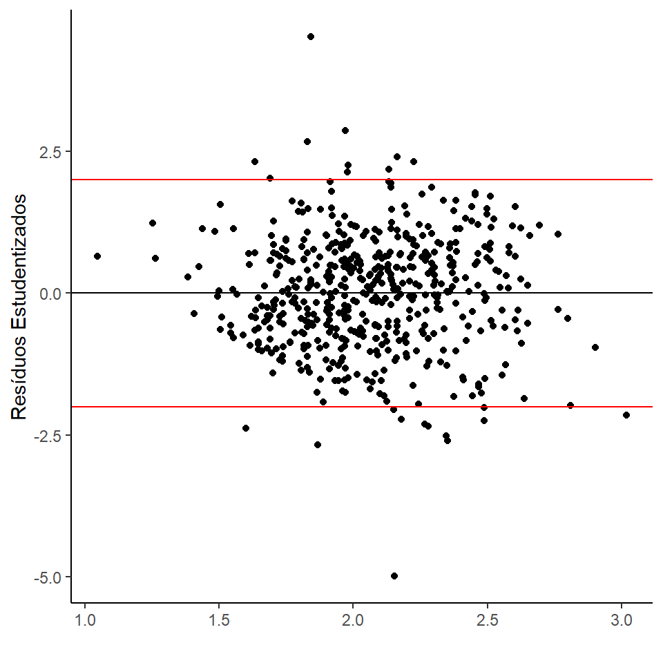

```r
ggplot(mod_log, aes(mod_log$fitted.values,rstudent(mod_log)))+
  geom_point()+
  xlab("")+
  ylab("Resíduos Estudentizados")+
  geom_hline(yintercept=0)+
  geom_hline(yintercept=2, color="red")+
  geom_hline(yintercept=-2, color="red")+
  theme_classic()
```

Corrigiu o problema de homocedasticidade mas ainda existem pontos acima e abaixo das linhas.

### QQplot do *log(wages)*

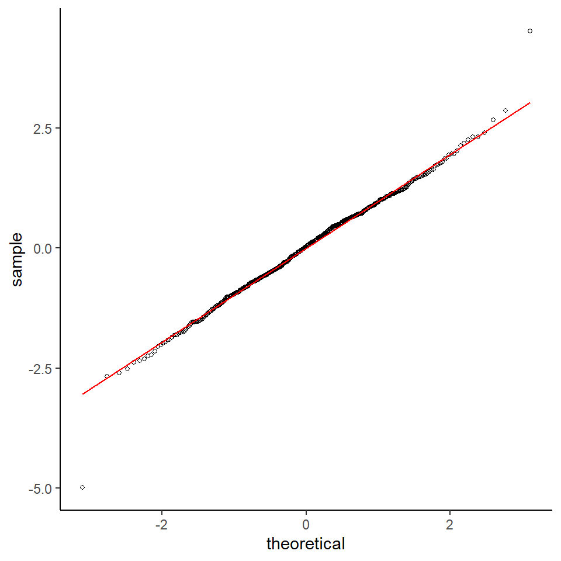

```r
ggplot(mod_log, aes(sample=rstudent(mod_log)))+
  stat_qq(shape=1, size=1)+
  stat_qq_line(color="red")+
  theme_classic()
```

Há problemas de adequação nas pontas do gráfico.

### Normalidade

```r
ks.test(rstudent(mod_log),"pnorm")
```

```
##
##  One-sample Kolmogorov-Smirnov test
##
## data:  rstudent(mod_log)
## D = 0.028945, p-value = 0.7622
## alternative hypothesis: two-sided
```

Verificando a normalidade dos ressíduos do novo modelo, levando em consideração $\alpha = 0,05$, não rejeitamos a hipótese nula, que afirma a suposição de normalidade.

### Box-Cox

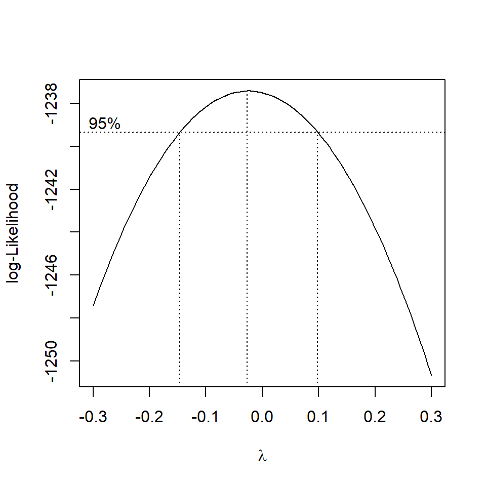

```r
require(MASS)
boxcox(mod, plotit = TRUE, data=df,lambda = seq(-.3, .3, by = .01))
```

Com Box-Cox podemos assegurar que a melhor transformação é a *log(wages)*, pois o valor de $\lambda$ está muito próximo de zero.

# Questão 2

## Dados

```r
df <- c(rep(0,57),rep(1,203),rep(2,383),rep(3,525),rep(4,532),rep(5,408),rep(6,273),rep(7,139),rep(8,45),rep(9,27),rep(10,10),rep(11,4),rep(12,0),rep(13,1),rep(14,1),rep(15,0))
```

## Medidas

```r
mean(df)
```

```
## [1] 3.871549
```

```r
var(df)
```

```
## [1] 3.696191
```

# Questão 3

## Dados

```r
df <- c(rep(0,215),rep(1,1485),rep(2,5331),rep(3,10649),rep(4,14959),rep(5,11929),rep(6,6678),rep(7,2092),rep(8,342))
```

## Medidas

```r
cbind("Médias" = c(mean(df),9*.5),
      "Variância" = c(var(df),9*.25)) %>%
  magrittr::set_rownames(c("dados","estimada")) %>%
  kable() %>%
  kable_paper("hover", full_width = F)
```

|  | Médias | Variância |
| --- | --- | --- |
| dados | 4.117418 | 2.067455 |
| estimada | 4.500000 | 2.250000 |